# Cross-country spillovers from the refined core system (stage 2c)

Demand, monetary and oil shocks on the four-refinement system — and what survives a seed placebo

## 1. What this is, and what is different from stage 2b

This is the same battery `reports/stage2_spillovers.qmd` ran, re-run on the **stage 2c** system: eleven countries, four refinements, `k = 76` and `df = 22` — *identical* to stage 2b. That equality is what makes this report worth writing. Every previous extension in this project traded degrees of freedom for structure, so a change in the spillover matrix could always be attributed to a thinner posterior; here it cannot.

Method, unchanged from stage 2b and not re-derived here:

- koma has **no impulse-response function**. A shock response is two `koma::forecast()` calls — one unconditional, one with `restrictions =` — differenced, with `set.seed()` immediately before each so the two legs share the identical innovation draw (`scenario_diff()`).
- **Demand shocks**: `<iso2>_gdp` growth restricted to baseline **+1pp at horizon 1 only**. A one-quarter growth impulse, not a permanent level step.
- **Monetary shock**: `ea_policy_rate` at baseline **+100bp for 4 quarters**.
- **Oil shock**: `oil_price` **level ×1.5**, sustained. Oil is exogenous, so it cannot use `restrictions` at all — a whole shocked copy of the fit is built instead.
- Every table is keyed off **`median_diff`**, never `mean_diff` — see §2.

How each exogenous series was extended to reach an 8-quarter horizon. Trailing-momentum continuation, not a forecast of oil markets or world trade.

| variable | method | periods_added |
| --- | --- | --- |
| covid_2020q1 | zero (dummy) | 3 |
| covid_2020q2 | zero (dummy) | 3 |
| covid_2020q3 | zero (dummy) | 3 |
| covid_2021q2 | zero (dummy) | 3 |
| eur_usd | trailing-4Q avg growth (2.67%/q) | 3 |
| oil_price | trailing-4Q avg growth (1.41%/q) | 3 |
| row_gdp | trailing-4Q avg growth (0.72%/q) | 3 |

## 2. Numerical health of the posterior

### 2.1 Explosive draws

koma’s Gibbs sampler places no stationarity constraint on a draw’s coefficients, so on a system of this size a real share of posterior draws are dynamically explosive. This is a property of the fitted posterior, not a bug, and it is why every point estimate below is a median.

Averaged over all eleven demand shocks and all eleven GDP variables.

| Horizon | Mean explosive share across GDP variables |
| --- | --- |
| 1 | 0.035 |
| 2 | 0.146 |
| 3 | 0.260 |
| 4 | 0.347 |
| 5 | 0.423 |
| 6 | 0.480 |
| 7 | 0.522 |
| 8 | 0.558 |

At horizon 8, 549 of 1000 unconditional baseline draws exceed `|de_gdp| > 100` — 54.9%, against the 56.8% `reports/stage2_spillovers.qmd` recorded for stage 2b. Materially the same; stage 2c does not fix the explosive-draw population, and was not expected to.

### 2.2 Draws the monetary restriction kills outright

A sustained 4-quarter restriction is a different failure mode from an extreme value: restricting four horizons at once requires inverting `R %*% Omega %*% t(R)`, and for a numerically rank-deficient draw no valid conditional innovation exists. koma drops such draws by **subsetting the list**, recording nothing about which index they were, so `scenario_diff()` aborts on the draw-count mismatch rather than silently mispair the common random numbers.

`failed_restriction_draws()` recovers the indices by tracing `koma:::forecast_draw()` and asking, per draw, whether it returned normally.

Verification before dropping them from the baseline leg.

| quantity | value |
| --- | --- |
| draws attempted | 1000 |
| draws failing the conditional solve | 40 |
| of those, also explosive in the unconditional baseline | 40 of 40 |
| identical failing index set at the placebo seed | TRUE |

Both checks matter. **All 40 failing draws are also explosive** — the same badly-behaved population surfacing as an outright failure under a demanding restriction and as a blow-up without one, exactly as stage 2b found (38 of 38 there). And the failing set is **identical at both seeds**, not merely the same size, which is the prediction the mechanism makes: failure depends on the draw’s posterior `Omega`, which carries no RNG, while the seed controls only the innovation draw.

## 3. German demand shock

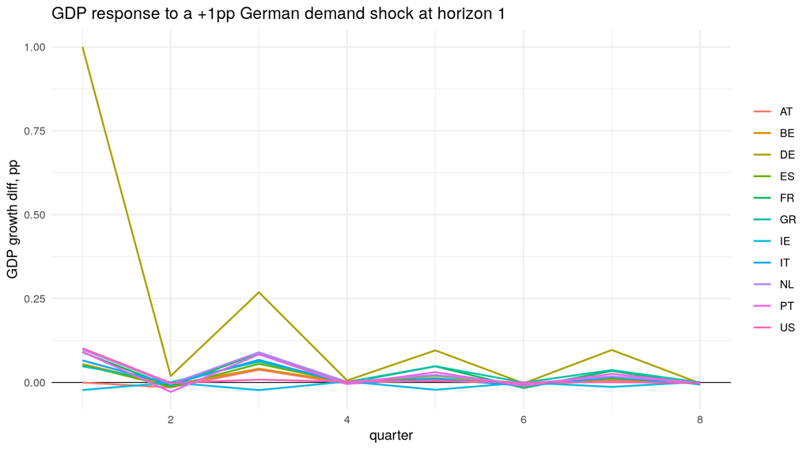

GDP response by country, quarters 1-8.

| country | horizon | median_diff | ci_low | ci_high | explosive_frac |
| --- | --- | --- | --- | --- | --- |
| AT | 1 | -0.0003 | -3.952180e+01 | 4.500060e+01 | 0.069 |
| AT | 2 | -0.0148 | -1.901502e+02 | 3.079516e+02 | 0.185 |
| AT | 3 | 0.0379 | -1.768503e+03 | 2.452823e+03 | 0.307 |
| AT | 4 | -0.0036 | -1.053368e+04 | 4.336299e+04 | 0.391 |
| AT | 5 | 0.0082 | -1.851251e+05 | 2.464419e+05 | 0.462 |
| AT | 6 | -0.0080 | -9.147663e+05 | 4.685632e+06 | 0.498 |
| AT | 7 | 0.0062 | -2.081785e+07 | 2.654425e+07 | 0.550 |
| AT | 8 | -0.0032 | -5.976922e+07 | 7.412598e+08 | 0.579 |
| BE | 1 | 0.0548 | -2.514370e+01 | 2.254170e+01 | 0.039 |
| BE | 2 | -0.0073 | -1.156681e+02 | 1.545004e+02 | 0.155 |
| BE | 3 | 0.0410 | -1.383658e+03 | 9.588913e+02 | 0.265 |
| BE | 4 | -0.0002 | -5.198048e+03 | 1.615072e+04 | 0.350 |
| BE | 5 | 0.0126 | -1.533782e+05 | 6.069513e+04 | 0.432 |
| BE | 6 | -0.0070 | -3.685879e+05 | 2.422294e+06 | 0.490 |
| BE | 7 | 0.0090 | -9.904331e+06 | 4.096608e+06 | 0.527 |
| BE | 8 | -0.0019 | -3.212915e+07 | 2.674648e+08 | 0.558 |
| DE | 1 | 1.0000 | -3.354700e+01 | 3.834900e+01 | 0.033 |
| DE | 2 | 0.0193 | -1.568729e+02 | 1.722702e+02 | 0.159 |
| DE | 3 | 0.2688 | -1.218258e+03 | 1.410942e+03 | 0.273 |
| DE | 4 | 0.0059 | -6.175691e+03 | 1.863558e+04 | 0.363 |
| DE | 5 | 0.0956 | -8.495009e+04 | 1.815276e+05 | 0.436 |
| DE | 6 | -0.0026 | -3.774420e+05 | 2.061737e+06 | 0.497 |
| DE | 7 | 0.0967 | -7.745096e+06 | 2.883660e+07 | 0.532 |
| DE | 8 | -0.0023 | -3.247948e+07 | 3.255874e+08 | 0.562 |
| ES | 1 | 0.0522 | -1.357690e+01 | 1.207960e+01 | 0.017 |
| ES | 2 | -0.0134 | -5.871960e+01 | 7.682160e+01 | 0.105 |
| ES | 3 | 0.0554 | -6.105950e+02 | 7.688760e+02 | 0.225 |
| ES | 4 | -0.0001 | -2.509461e+03 | 8.920583e+03 | 0.315 |
| ES | 5 | 0.0200 | -6.831306e+04 | 4.258711e+04 | 0.389 |
| ES | 6 | -0.0041 | -1.674951e+05 | 9.066128e+05 | 0.453 |

[output cut: 58 more lines]

## 4. US demand shock

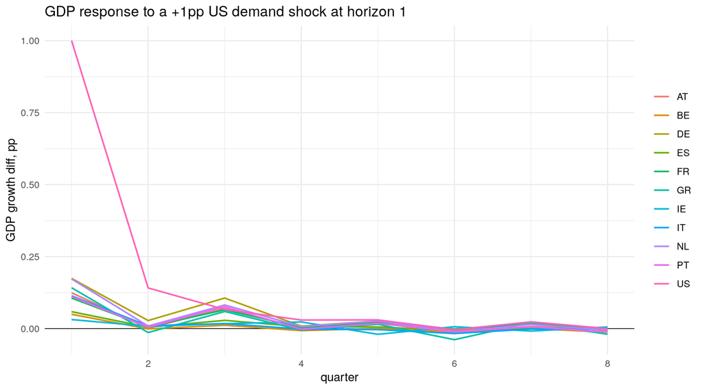

GDP response by country, quarters 1-8.

| country | horizon | median_diff | ci_low | ci_high | explosive_frac |
| --- | --- | --- | --- | --- | --- |
| AT | 1 | 0.1245 | -2.159080e+01 | 2.807360e+01 | 0.075 |
| AT | 2 | 0.0015 | -1.047728e+02 | 1.668464e+02 | 0.185 |
| AT | 3 | 0.0698 | -7.469099e+02 | 1.846252e+03 | 0.296 |
| AT | 4 | 0.0010 | -6.942259e+03 | 1.933419e+04 | 0.394 |
| AT | 5 | 0.0211 | -8.360304e+04 | 2.552598e+05 | 0.456 |
| AT | 6 | -0.0145 | -7.707321e+05 | 2.748936e+06 | 0.503 |
| AT | 7 | 0.0076 | -6.331546e+06 | 2.967465e+07 | 0.542 |
| AT | 8 | -0.0026 | -5.996210e+07 | 3.923114e+08 | 0.585 |
| BE | 1 | 0.0498 | -1.665960e+01 | 1.833090e+01 | 0.040 |
| BE | 2 | -0.0010 | -9.563420e+01 | 9.411700e+01 | 0.158 |
| BE | 3 | 0.0117 | -1.043613e+03 | 8.471439e+02 | 0.262 |
| BE | 4 | -0.0069 | -5.763467e+03 | 9.341218e+03 | 0.347 |
| BE | 5 | 0.0006 | -6.714086e+04 | 4.532207e+04 | 0.431 |
| BE | 6 | -0.0120 | -4.052336e+05 | 9.795747e+05 | 0.481 |
| BE | 7 | 0.0003 | -7.078657e+06 | 4.555061e+06 | 0.524 |
| BE | 8 | -0.0125 | -4.178308e+07 | 8.932268e+07 | 0.560 |
| DE | 1 | 0.1743 | -2.212400e+01 | 1.926380e+01 | 0.037 |
| DE | 2 | 0.0281 | -1.337886e+02 | 1.076588e+02 | 0.164 |
| DE | 3 | 0.1062 | -7.714752e+02 | 1.172847e+03 | 0.266 |
| DE | 4 | 0.0086 | -5.738861e+03 | 1.318109e+04 | 0.360 |
| DE | 5 | 0.0264 | -5.632567e+04 | 9.382809e+04 | 0.433 |
| DE | 6 | -0.0074 | -4.673355e+05 | 1.136674e+06 | 0.497 |
| DE | 7 | 0.0214 | -4.308094e+06 | 8.950881e+06 | 0.537 |
| DE | 8 | -0.0080 | -4.941007e+07 | 1.243691e+08 | 0.559 |
| ES | 1 | 0.0588 | -1.042140e+01 | 9.725600e+00 | 0.018 |
| ES | 2 | 0.0051 | -4.070070e+01 | 5.225390e+01 | 0.104 |
| ES | 3 | 0.0286 | -4.378412e+02 | 3.205977e+02 | 0.225 |
| ES | 4 | 0.0065 | -2.119753e+03 | 4.178397e+03 | 0.313 |
| ES | 5 | 0.0056 | -3.422687e+04 | 1.939075e+04 | 0.391 |
| ES | 6 | -0.0063 | -1.587739e+05 | 4.129527e+05 | 0.454 |

[output cut: 58 more lines]

## 5. Common monetary shock

`ea_policy_rate` +100bp, sustained for 4 quarters, with the 40 singular-solve draws of §2.2 dropped from both legs.

This is the shock stage 2c exists for. Stage 2b’s `ea_policy_rate` reached 91 of 103 endogenous variables and **not one price**, so the Taylor rule’s inflation term responded to something nothing it did could influence; stage 2c’s reaches all 114, all 12 prices included. The structural gap is closed and exactly verifiable. The question here is whether the numbers moved.

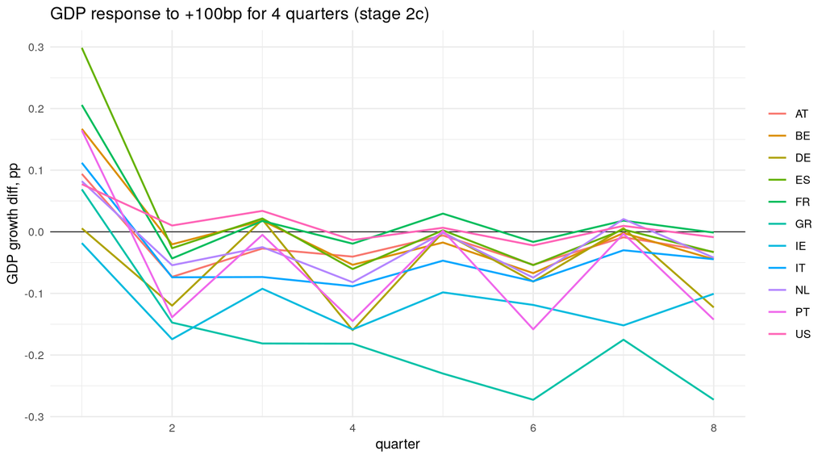

GDP response by country.

| country | horizon | median_diff | ci_low | ci_high | explosive_frac |
| --- | --- | --- | --- | --- | --- |
| AT | 1 | 0.0939 | -3.335320e+01 | 4.441810e+01 | 0.0594 |
| AT | 2 | -0.0731 | -1.034619e+02 | 3.153035e+02 | 0.1479 |
| AT | 3 | -0.0271 | -1.147046e+03 | 1.046080e+03 | 0.2635 |
| AT | 4 | -0.0403 | -3.192247e+03 | 1.811039e+04 | 0.3552 |
| AT | 5 | -0.0059 | -9.337713e+04 | 3.547939e+04 | 0.4271 |
| AT | 6 | -0.0535 | -1.545967e+05 | 8.514094e+05 | 0.4781 |
| AT | 7 | -0.0089 | -6.911318e+06 | 1.464609e+06 | 0.5208 |
| AT | 8 | -0.0327 | -6.914355e+06 | 4.742947e+07 | 0.5615 |
| BE | 1 | 0.1671 | -2.245360e+01 | 2.384130e+01 | 0.0240 |
| BE | 2 | -0.0203 | -9.751810e+01 | 1.295098e+02 | 0.1187 |
| BE | 3 | 0.0181 | -9.389106e+02 | 7.430483e+02 | 0.2240 |
| BE | 4 | -0.0536 | -4.107800e+03 | 8.269831e+03 | 0.3125 |
| BE | 5 | -0.0174 | -5.213795e+04 | 3.562196e+04 | 0.3979 |
| BE | 6 | -0.0671 | -1.582923e+05 | 3.345714e+05 | 0.4542 |
| BE | 7 | -0.0020 | -2.011354e+06 | 1.424598e+06 | 0.5021 |
| BE | 8 | -0.0446 | -9.013133e+06 | 2.861375e+07 | 0.5354 |
| DE | 1 | 0.0055 | -2.942450e+01 | 2.710800e+01 | 0.0271 |
| DE | 2 | -0.1198 | -1.225962e+02 | 1.453195e+02 | 0.1229 |
| DE | 3 | 0.0196 | -6.151034e+02 | 7.901388e+02 | 0.2281 |
| DE | 4 | -0.1597 | -4.352495e+03 | 7.701345e+03 | 0.3208 |
| DE | 5 | -0.0008 | -3.761298e+04 | 3.736214e+04 | 0.4000 |
| DE | 6 | -0.0808 | -1.629240e+05 | 6.042865e+05 | 0.4781 |
| DE | 7 | 0.0059 | -2.228788e+06 | 3.115230e+06 | 0.5094 |
| DE | 8 | -0.1227 | -8.115334e+06 | 3.183205e+07 | 0.5417 |
| ES | 1 | 0.2986 | -1.219730e+01 | 1.172940e+01 | 0.0135 |
| ES | 2 | -0.0266 | -5.895640e+01 | 5.892580e+01 | 0.0719 |
| ES | 3 | 0.0216 | -4.513828e+02 | 3.855513e+02 | 0.1802 |
| ES | 4 | -0.0605 | -2.113679e+03 | 4.280572e+03 | 0.2708 |
| ES | 5 | 0.0024 | -2.436928e+04 | 1.788900e+04 | 0.3552 |
| ES | 6 | -0.0541 | -1.021785e+05 | 2.129343e+05 | 0.4271 |

[output cut: 58 more lines]

Price response by country.

| country | horizon | median_diff | ci_low | ci_high | explosive_frac |
| --- | --- | --- | --- | --- | --- |
| AT | 1 | 0.0151 | -2.2916 | 3.0374 | 0.0031 |
| AT | 2 | 0.0065 | -8.3673 | 18.1765 | 0.0312 |
| AT | 3 | 0.0062 | -81.2210 | 71.0492 | 0.0917 |
| AT | 4 | -0.0017 | -218.4765 | 1149.0434 | 0.1729 |
| AT | 5 | 0.0023 | -7403.6468 | 1572.5779 | 0.2417 |
| AT | 6 | -0.0030 | -12342.6007 | 65927.2912 | 0.3021 |
| AT | 7 | 0.0022 | -678664.5207 | 90346.6928 | 0.3552 |
| AT | 8 | -0.0055 | -765491.1180 | 2126021.9937 | 0.3958 |
| BE | 1 | 0.0603 | -4.4549 | 4.4734 | 0.0031 |
| BE | 2 | 0.0261 | -23.9095 | 21.3790 | 0.0312 |
| BE | 3 | 0.0049 | -157.3420 | 140.7816 | 0.1177 |
| BE | 4 | -0.0014 | -1298.5712 | 682.2537 | 0.2021 |
| BE | 5 | 0.0057 | -6922.8898 | 9672.5791 | 0.2740 |
| BE | 6 | 0.0002 | -80634.0237 | 28675.6533 | 0.3292 |
| BE | 7 | -0.0013 | -287527.1811 | 403786.4294 | 0.3865 |
| BE | 8 | -0.0013 | -4618085.4118 | 1360634.8908 | 0.4458 |
| DE | 1 | 0.1367 | -2.1249 | 2.7359 | 0.0010 |
| DE | 2 | 0.0593 | -13.3009 | 6.7321 | 0.0198 |
| DE | 3 | 0.0290 | -71.9446 | 49.4490 | 0.0771 |
| DE | 4 | 0.0071 | -881.6938 | 127.0561 | 0.1458 |
| DE | 5 | 0.0115 | -5243.8495 | 1932.8072 | 0.2177 |
| DE | 6 | 0.0003 | -59843.9793 | 3757.5175 | 0.2812 |
| DE | 7 | -0.0023 | -240101.5724 | 74014.0248 | 0.3448 |
| DE | 8 | 0.0033 | -3064147.0632 | 134657.1122 | 0.4000 |
| ES | 1 | 0.1222 | -2.3037 | 3.3902 | 0.0010 |
| ES | 2 | 0.0274 | -13.2058 | 11.2095 | 0.0208 |
| ES | 3 | 0.0069 | -78.5793 | 64.9972 | 0.0854 |
| ES | 4 | -0.0014 | -320.0022 | 642.7766 | 0.1698 |
| ES | 5 | -0.0004 | -4295.6553 | 2789.7840 | 0.2375 |
| ES | 6 | -0.0129 | -14403.9712 | 45404.1317 | 0.3010 |

[output cut: 58 more lines]

### 5.1 Against stage 2b

GDP: peak horizon, peak value and cumulative 8-quarter effect.

| country | peak_horizon_2b | peak_2b | cumulative_2b | peak_horizon_2c | peak_2c | cumulative_2c |
| --- | --- | --- | --- | --- | --- | --- |
| AT | 1 | 0.481 | -0.271 | 1 | 0.094 | -0.148 |
| BE | 1 | 0.213 | 0.033 | 1 | 0.167 | -0.020 |
| DE | 1 | 0.177 | -0.020 | 4 | -0.160 | -0.453 |
| ES | 1 | 0.197 | -0.100 | 1 | 0.299 | 0.152 |
| FR | 1 | 0.202 | 0.040 | 1 | 0.206 | 0.191 |
| GR | 1 | 0.146 | 0.385 | 6 | -0.273 | -1.392 |
| IE | 1 | 0.155 | 0.140 | 2 | -0.174 | -0.913 |
| IT | 2 | -0.260 | -0.186 | 1 | 0.112 | -0.325 |
| NL | 1 | 0.231 | -0.480 | 1 | 0.082 | -0.176 |
| PT | 4 | -0.240 | -0.595 | 1 | 0.165 | -0.426 |
| US | 2 | 0.027 | 0.043 | 1 | 0.077 | 0.093 |

Out of 11 countries.

| measure | stage2b | stage2c |
| --- | --- | --- |
| GDP peaks at horizon 1 | 8 | 8 |
| GDP peak negative | 2 | 3 |
| GDP cumulative negative | 6 | 8 |
| price peak negative | 1 | 0 |

**The GDP response is still dominated by the horizon-1 echo.** Eight of eleven still peak at horizon 1 with a positive value — the same-quarter artefact of imposing an exact-value restriction, diagnosed in stage 2b’s §1.3.

**The apparent gain in cumulative GDP sign does not survive the placebo** — see §9.1. Greece and Ireland are the exceptions, and the only two countries whose monetary response can honestly be called changed.

## 6. Oil shock

Price response to a sustained oil price level x1.5 (stage 2c).

| country | peak_horizon | peak | cumulative |
| --- | --- | --- | --- |
| AT | 1 | 0.514 | 1.872 |
| BE | 1 | 0.896 | 1.598 |
| DE | 1 | 0.801 | 1.937 |
| ES | 1 | 0.849 | 1.216 |
| FR | 1 | 0.555 | 1.430 |
| GR | 1 | 0.585 | 1.388 |
| IE | 1 | 0.647 | 2.250 |
| IT | 1 | 0.453 | 0.821 |
| NL | 1 | 0.490 | 0.939 |
| PT | 1 | 0.529 | 1.067 |
| US | 1 | 1.099 | 1.793 |

Full path by country.

| country | horizon | median_diff | ci_low | ci_high | explosive_frac |
| --- | --- | --- | --- | --- | --- |
| AT | 1 | 0.5140 | 0.1191 | 0.9216 | 0.005 |
| AT | 2 | 0.3815 | -0.0585 | 0.8878 | 0.050 |
| AT | 3 | 0.2882 | -2.1993 | 2.5106 | 0.126 |
| AT | 4 | 0.2213 | -15.9151 | 21.0418 | 0.205 |
| AT | 5 | 0.1649 | -195.3123 | 224.4315 | 0.269 |
| AT | 6 | 0.1326 | -1449.4290 | 3146.6693 | 0.328 |
| AT | 7 | 0.0925 | -22822.7182 | 24587.2485 | 0.380 |
| AT | 8 | 0.0775 | -144029.9682 | 519054.3933 | 0.416 |
| BE | 1 | 0.8963 | 0.1103 | 1.5653 | 0.006 |
| BE | 2 | 0.3716 | -0.1994 | 1.1298 | 0.057 |
| BE | 3 | 0.1664 | -2.2837 | 5.3535 | 0.153 |
| BE | 4 | 0.0841 | -54.3944 | 11.3361 | 0.235 |
| BE | 5 | 0.0406 | -121.5100 | 442.7670 | 0.302 |
| BE | 6 | 0.0226 | -6635.9675 | 822.9330 | 0.356 |
| BE | 7 | 0.0106 | -10390.4140 | 51096.5289 | 0.406 |
| BE | 8 | 0.0062 | -1361194.5679 | 58881.7692 | 0.464 |
| DE | 1 | 0.8015 | 0.3405 | 1.2853 | 0.003 |
| DE | 2 | 0.4482 | 0.0713 | 1.1253 | 0.037 |
| DE | 3 | 0.2668 | -1.9236 | 2.3843 | 0.114 |
| DE | 4 | 0.1606 | -12.0918 | 25.9974 | 0.181 |
| DE | 5 | 0.1037 | -180.2122 | 168.0056 | 0.249 |
| DE | 6 | 0.0700 | -890.6629 | 2170.7609 | 0.310 |
| DE | 7 | 0.0512 | -24040.1529 | 15099.1443 | 0.366 |
| DE | 8 | 0.0346 | -160314.1461 | 263720.0906 | 0.419 |
| ES | 1 | 0.8490 | 0.2494 | 1.4331 | 0.002 |
| ES | 2 | 0.2424 | -0.1013 | 0.7569 | 0.039 |
| ES | 3 | 0.0756 | -2.4211 | 1.5022 | 0.120 |
| ES | 4 | 0.0322 | -21.7517 | 17.4266 | 0.204 |
| ES | 5 | 0.0081 | -181.1513 | 116.2236 | 0.269 |
| ES | 6 | 0.0072 | -1465.6032 | 1277.3189 | 0.329 |

[output cut: 58 more lines]

All eleven positive, cumulative 0.8–2.3pp, peaking on impact and persisting. This is the control that makes §5 interpretable: the price block responds sensibly and with the right sign to a genuine cost-push shock, and perversely to a policy rate. The fault is not in the price equations.

## 7. The spillover matrix

Stage 2c: cumulative 8-quarter GDP response, source (row) x receiver (column).

|  | at | be | de | gr | es | fr | ie | it | nl | pt | us |
| --- | --- | --- | --- | --- | --- | --- | --- | --- | --- | --- | --- |
| at | 1.273 | 0.126 | 0.129 | 0.321 | 0.067 | 0.108 | -0.026 | 0.051 | 0.147 | 0.201 | 0.043 |
| be | 0.076 | 1.124 | 0.087 | 0.313 | 0.168 | 0.215 | -0.016 | 0.169 | 0.304 | 0.276 | 0.098 |
| de | 0.023 | 0.101 | 1.481 | 0.197 | 0.121 | 0.224 | -0.076 | 0.136 | 0.221 | 0.185 | 0.115 |
| gr | 0.086 | 0.041 | 0.061 | 1.553 | 0.043 | 0.037 | 0.052 | 0.027 | 0.071 | 0.086 | 0.057 |
| es | 0.279 | 0.335 | 0.271 | 0.365 | 1.155 | 0.377 | 0.113 | 0.267 | 0.455 | 0.640 | 0.234 |
| fr | 0.275 | 0.601 | 0.309 | 0.586 | 0.417 | 1.448 | 0.185 | 0.389 | 0.716 | 0.491 | 0.293 |
| ie | -0.044 | -0.033 | 0.049 | -0.041 | 0.006 | 0.012 | 0.955 | 0.014 | 0.001 | -0.024 | 0.038 |
| it | 0.371 | 0.462 | 0.555 | 0.512 | 0.566 | 0.446 | 0.078 | 1.163 | 0.793 | 0.640 | 0.270 |
| nl | 0.116 | 0.239 | 0.394 | 0.282 | 0.258 | 0.354 | 0.125 | 0.333 | 1.290 | 0.420 | 0.215 |
| pt | 0.243 | 0.224 | 0.179 | 0.261 | 0.330 | 0.363 | 0.063 | 0.152 | 0.366 | 1.270 | 0.100 |
| us | 0.208 | 0.030 | 0.350 | 0.160 | 0.099 | 0.216 | 0.064 | 0.115 | 0.296 | 0.192 | 1.287 |

Own-effect diagonals. Stage 2c’s are tighter as well as uniformly dominant.

| country | own_2b | own_2c |
| --- | --- | --- |
| at | 1.479 | 1.273 |
| be | 1.662 | 1.124 |
| de | 1.378 | 1.481 |
| gr | 1.001 | 1.553 |
| es | 1.430 | 1.155 |
| fr | 1.658 | 1.448 |
| ie | 0.809 | 0.955 |
| it | 1.371 | 1.163 |
| nl | 1.008 | 1.290 |
| pt | 0.782 | 1.270 |
| us | 1.314 | 1.287 |

`CLAUDE.md` is emphatic that an individual cell of this matrix is not a reliable number at 1000 draws. Read it as a pattern — sign, rough ordering, and whether the own effect dominates — never cell by cell. §9 quantifies exactly how unreliable a cell is, and the answer for stage 2c is *notably better than for stage 2b*.

## 8. Sanity checks

All three checks, both systems, reported as-is.

| check | stage2b | stage2c |
| --- | --- | --- |
| own effect exceeds every cross-country effect | FAIL — 7/11 countries: own > max\|cross\| | PASS — 11/11 countries: own > max\|cross\| |
| monetary contraction is negative for GDP and prices everywhere | FAIL — GDP peak negative: 2/11 \| prices peak negative: 1/11 | FAIL — GDP peak negative: 3/11 \| prices peak negative: 0/11 |
| spillover magnitude correlates with bilateral trade weight | FAIL — Spearman rho = 0.141 (pass threshold: > 0.3) | FAIL — Spearman rho = 0.292 (pass threshold: > 0.3) |

### 8.1 Own effect: 7/11 → 11/11, and the Austria artefact is gone

Stage 2b failed this for four countries. A French, German or Belgian demand shock moved *Austrian* GDP more than it moved the source’s own — an indirect two-hop path through Germany, which §7.1 of that report analysed at length and concluded was a legitimate property of a simultaneous system rather than a defect. Under stage 2c the own effect dominates in **11 of 11**.

Austria’s stage-2c foreign_demand weights – now over partner IMPORTS, with row_gdp the unmodelled-world residual.

| loads_on | weight |
| --- | --- |
| be_imports | 0.027 |
| de_imports | 0.286 |
| es_imports | 0.019 |
| fr_imports | 0.036 |
| ie_imports | 0.016 |
| it_imports | 0.056 |
| nl_imports | 0.049 |
| us_imports | 0.058 |
| row_gdp | 0.453 |

The plausible mechanism is refinement 2. Austria’s exposure is unchanged as a set of trade weights, but what those weights now multiply is partner *imports* rather than partner *GDP*. A German demand shock raises German GDP a lot and German imports proportionally less, so the two-hop path into Austria is damped relative to the source’s own response. This report does not claim to have isolated that mechanism — it is the reading consistent with the change, and the alternative explanations (the Phillips curve, the spread) do not touch the demand-propagation path at all.

### 8.2 Trade-weight correlation: 0.141 → 0.292, still failing

Better by more than a factor of two, and still short of the 0.3 threshold. The structural argument stage 2b’s §7.3 made still applies: this check correlates each cell against the receiver’s **direct** bilateral weight on the source, in a system where a large share of any country’s total exposure runs through third countries. A network-aware version would be the right test, and remains follow-up work.

**This number would not exist at all without a fix made for this stage.** `spillover_sanity_checks()` looked each source up as `<source>_gdp` in the receiver’s `foreign_demand` weights. Stage 2c’s identity loads partner **imports**, so under the old code every lookup missed, the weight column came out all zeros, and the reported correlation was computed against a constant — a meaningless verdict rather than an error. The lookup now matches on the ISO-2 prefix, which also repairs the same latent bug under `ireland_proxy`.

## 9. The seed placebo

Common random numbers make a *baseline-vs-scenario* pair exact. They do nothing about sampling error in the level of the estimand itself, which is a median over draws of which more than half have exploded by horizon 8. So before any of §5–§8 is read as a stage-2c effect, the same four source countries were re-run at a second seed **on the same fit**. Anything smaller than that gap is noise.

Four sources (de, fr, it, nl) x 11 receivers = 44 cells.

| comparison | mean_abs_diff | max_abs_diff | sign_flips |
| --- | --- | --- | --- |
| seed A vs seed B, same stage-2c fit (noise) | 0.119 | 0.356 | 1 |
| stage 2c vs stage 2b, same seed (the claim) | 0.396 | 1.675 | 3 |

Two readings, and the second is the more valuable.

**The matrix change is signal.** The cross-system difference is 3.3x the seed-to-seed spread, and 26 of 44 cells move by more than twice the noise.

**Stage 2c’s matrix is about three times more reproducible than stage 2b’s.** `CLAUDE.md` records stage 2b’s own seed sensitivity: an off-diagonal cell moved by **0.35 on average, up to 1.85, flipping the sign of 7–10 of 30**. The same measurement on stage 2c gives 0.119, 0.356, and **1 of 44**. That is not a claim that can itself be dismissed as noise — it is a measurement *of* the noise — and it is the strongest single result in this report. A matrix whose cells were previously too unstable to read individually is now substantially closer to being readable.

Own diagonals. A change is reportable only where the system gap clearly exceeds the seed spread.

| country | own_2b | own_2c_seedA | own_2c_seedB | seed_spread | system_gap |
| --- | --- | --- | --- | --- | --- |
| de | 1.378 | 1.481 | 1.298 | 0.183 | 0.103 |
| fr | 1.658 | 1.448 | 1.432 | 0.016 | 0.210 |
| it | 1.371 | 1.163 | 1.129 | 0.034 | 0.209 |
| nl | 1.008 | 1.290 | 1.311 | 0.021 | 0.282 |

France, Italy and the Netherlands move by roughly ten times their seed spread and can be reported. **Germany’s diagonal moves by less than its own seed spread (0.103 against 0.183) and must not be.** The same discipline that killed the two largest apparent findings in `reports/stage3c_rollout.qmd` §4.4 applies here and lands on a different country.

### 9.1 The monetary shock does not survive it

Out of 11. Seeds A and B are the SAME stage-2c fit, so any gap between those two columns is pure noise.

| measure | stage2b | stage2c_seedA | stage2c_seedB |
| --- | --- | --- | --- |
| GDP cumulative negative | 6 | 8 | 6 |
| GDP peak negative | 2 | 3 | 4 |
| price peak negative | 1 | 0 | 1 |

Cumulative 8-quarter GDP response to the monetary shock, per country.

| country | cumulative_seedA | cumulative_seedB | cumulative_2b | seed_gap | system_gap | survives |
| --- | --- | --- | --- | --- | --- | --- |
| AT | -0.148 | 0.000 | -0.271 | 0.148 | 0.124 | FALSE |
| BE | -0.020 | 0.337 | 0.033 | 0.357 | 0.053 | FALSE |
| DE | -0.453 | -0.824 | -0.020 | 0.371 | 0.433 | FALSE |
| ES | 0.152 | 0.408 | -0.100 | 0.256 | 0.252 | FALSE |
| FR | 0.191 | 0.396 | 0.040 | 0.205 | 0.150 | FALSE |
| GR | -1.392 | -1.199 | 0.385 | 0.192 | 1.777 | TRUE |
| IE | -0.913 | -0.596 | 0.140 | 0.317 | 1.053 | TRUE |
| IT | -0.325 | -0.087 | -0.186 | 0.239 | 0.139 | FALSE |
| NL | -0.176 | 0.184 | -0.480 | 0.361 | 0.303 | FALSE |
| PT | -0.426 | -0.396 | -0.595 | 0.030 | 0.169 | TRUE |
| US | 0.093 | 0.366 | 0.043 | 0.273 | 0.050 | FALSE |

The count of countries with a negative cumulative GDP response is 8 at seed A and 6 at seed B — against 6 in stage 2b. **The stage-2c “improvement” is smaller than the distance between two runs of stage 2c itself**, so it is not a finding. Mean seed gap 0.250 against a mean cross-system gap of 0.409; for 7 of eleven the cross-system gap is *smaller* than the seed spread.

What survives is Greece (system gap 1.78 against a seed spread of 0.19) and Ireland (1.05 against 0.32), both substantially more contractionary under stage 2c and both among the countries whose response peaks at a later horizon. Portugal clears the same bar only because its seed spread is unusually small (0.030) on a movement of 0.17 in the opposite direction, and is better read as unresolvable than as a third finding. Germany’s gap (0.43) is not clearly above its seed spread (0.37).

## 10. Verdict

**The spillover structure is materially better; the monetary transmission is not.** Both halves of that are worth stating precisely, because the second is the one stage 2c was designed to fix.

Better, and it survives the placebo:

- The own-effect sanity check goes from **7/11 (fail) to 11/11 (pass)**. Stage 2b’s Austria two-hop artefact — the largest anomaly in that report — is gone.
- The trade-weight correlation **more than doubles** (0.141 → 0.292), though it still misses the threshold.
- The matrix is **~3× more seed-reproducible** (mean cell movement 0.119 against 0.35; one sign flip in 44 cells against 7–10 in 30). For a matrix whose cells `CLAUDE.md` warns must never be read individually, this is the most useful improvement of the three.

Not better:

The diagnosis is specific rather than a shrug. Closing the loop structurally was necessary — `ea_policy_rate` genuinely could not reach a single price variable before, and now reaches all twelve — but the fitted magnitudes along that path are tiny (`monetary_loop()` gives a contemporaneous round-trip gain around 1e-5, see `reports/stage2c_refined_core.qmd` §4.5), and 3 of 11 consumption-rate loadings are wrong-signed. The oil shock confirms the price block itself is sound. **What is missing is a lagged demand channel from the policy rate strong enough to outweigh the within-quarter restriction artefact** — not another contemporaneous link, which is what stage 2c added.